# Impact of Severe Weather Events on Public Health and the Economy in the United States

JeremiShane

10/12/2017

## Synopsis

From this analysis we see that Tornados have the highest impact for both health and economics. It appears that fatalities and injuries are produced similarly by natural disaster event types. We see some difference between property damage and crop damage, however, this is very likely due to crops not always being present in the locations accounted for.

This analysis uses a simple method for scoring health and economic impacts. Health impact is calculated by grouping all fatalities and injuries by natural disaster event type. Health impact score is used as the final measure which is 4x for each fatality added to 1x for each injury. Economic impact score is a grouping on event type with the property damage and crop damage added together.

## Environment

```r
s <- Sys.info()
s[3]  ## display sys info
```

```
##                                                                                            version
## "Darwin Kernel Version 16.7.0: Thu Jun 15 17:36:27 PDT 2017; root:xnu-3789.70.16~2/RELEASE_X86_64"
```

```r
r <- R.Version()
r$platform  ## Display OS and R version
```

```
## [1] "x86_64-apple-darwin15.6.0"
```

```r
r$version.string
```

```
## [1] "R version 3.4.1 (2017-06-30)"
```

```r
r$nickname
```

```
## [1] "Single Candle"
```

## Include Libraries

```r
library(plyr)
library(dplyr)
```

## Introduction

Storms and other severe weather events can cause both public health and economic problems for communities and municipalities. Many severe events can result in fatalities, injuries, and property damage, and preventing such outcomes to the extent possible is a key concern.

Consider writing your report as if it were to be read by a government or municipal manager who might be responsible for preparing for severe weather events and will need to prioritize resources for different types of events. However, there is no need to make any specific recommendations in your report.

## Data Processing

This project involves exploring the U.S. National Oceanic and Atmospheric Administration’s (NOAA) storm database. This database tracks characteristics of major storms and weather events in the United States, including when and where they occur, as well as estimates of any fatalities, injuries, and property damage.

### Data Fetch and Load

The data come in the form of a comma-separated-value file compressed via the bzip2 algorithm to reduce its size. You can download the file from:  
https://d396qusza40orc.cloudfront.net/repdata%2Fdata%2FStormData.csv.bz2

There is also some documentation of the database available. Here you will find how some of the variables are constructed/defined.

- National Weather Service Storm Data Documentation: https://d396qusza40orc.cloudfront.net/repdata%2Fpeer2_doc%2Fpd01016005curr.pdf
- National Climatic Data Center Storm Events FAQ: https://d396qusza40orc.cloudfront.net/repdata%2Fpeer2_doc%2FNCDC%20Storm%20Events-FAQ%20Page.pdf

```r
temp <- tempfile()
download.file("https://d396qusza40orc.cloudfront.net/repdata%2Fdata%2FStormData.csv.bz2", temp)
df <- read.csv(temp, strip.white=TRUE, na.strings="NA")
unlink(temp)
str(df)
```

```
## 'data.frame':    902297 obs. of  37 variables:
##  $ STATE__   : num  1 1 1 1 1 1 1 1 1 1 ...
##  $ BGN_DATE  : Factor w/ 16335 levels "1/1/1966 0:00:00",..: 6523 6523 4242 11116 2224 2224 2260 383 3980 3980 ...
##  $ BGN_TIME  : Factor w/ 3608 levels "00:00:00 AM",..: 272 287 2705 1683 2584 3186 242 1683 3186 3186 ...
##  $ TIME_ZONE : Factor w/ 22 levels "ADT","AKS","AST",..: 7 7 7 7 7 7 7 7 7 7 ...
##  $ COUNTY    : num  97 3 57 89 43 77 9 123 125 57 ...
##  $ COUNTYNAME: Factor w/ 29601 levels "","5NM E OF MACKINAC BRIDGE TO PRESQUE ISLE LT MI",..: 13513 1873 4598 10592 4372 10094 1973 23873 24418 4598 ...
##  $ STATE     : Factor w/ 72 levels "AK","AL","AM",..: 2 2 2 2 2 2 2 2 2 2 ...
##  $ EVTYPE    : Factor w/ 985 levels "   HIGH SURF ADVISORY",..: 834 834 834 834 834 834 834 834 834 834 ...
##  $ BGN_RANGE : num  0 0 0 0 0 0 0 0 0 0 ...
##  $ BGN_AZI   : Factor w/ 35 levels "","  N"," NW",..: 1 1 1 1 1 1 1 1 1 1 ...
##  $ BGN_LOCATI: Factor w/ 54429 levels ""," Christiansburg",..: 1 1 1 1 1 1 1 1 1 1 ...
##  $ END_DATE  : Factor w/ 6663 levels "","1/1/1993 0:00:00",..: 1 1 1 1 1 1 1 1 1 1 ...
##  $ END_TIME  : Factor w/ 3647 levels ""," 0900CST",..: 1 1 1 1 1 1 1 1 1 1 ...
##  $ COUNTY_END: num  0 0 0 0 0 0 0 0 0 0 ...
```

[output cut: 23 more lines]

```r
head(df)
```

| STATE__ | BGN_DATE | BGN_TIME | TIME_ZONE | COUNTY | COUNTYNAME | STATE | EVTYPE | BGN_RANGE | BGN_AZI | BGN_LOCATI | END_DATE | END_TIME | COUNTY_END | COUNTYENDN | END_RANGE | END_AZI | END_LOCATI | LENGTH | WIDTH | F | MAG | FATALITIES | INJURIES | PROPDMG | PROPDMGEXP | CROPDMG | CROPDMGEXP | WFO | STATEOFFIC | … |
| --- | --- | --- | --- | --- | --- | --- | --- | --- | --- | --- | --- | --- | --- | --- | --- | --- | --- | --- | --- | --- | --- | --- | --- | --- | --- | --- | --- | --- | --- | --- |
| 1 | 4/18/1950 0:00:00 | 0130 | CST | 97 | MOBILE | AL | TORNADO | 0 |  |  |  |  | 0 | NA | 0 |  |  | 14.0 | 100 | 3 | 0 | 0 | 15 | 25.0 | K | 0 |  |  |  | … |
| 1 | 4/18/1950 0:00:00 | 0145 | CST | 3 | BALDWIN | AL | TORNADO | 0 |  |  |  |  | 0 | NA | 0 |  |  | 2.0 | 150 | 2 | 0 | 0 | 0 | 2.5 | K | 0 |  |  |  | … |
| 1 | 2/20/1951 0:00:00 | 1600 | CST | 57 | FAYETTE | AL | TORNADO | 0 |  |  |  |  | 0 | NA | 0 |  |  | 0.1 | 123 | 2 | 0 | 0 | 2 | 25.0 | K | 0 |  |  |  | … |
| 1 | 6/8/1951 0:00:00 | 0900 | CST | 89 | MADISON | AL | TORNADO | 0 |  |  |  |  | 0 | NA | 0 |  |  | 0.0 | 100 | 2 | 0 | 0 | 2 | 2.5 | K | 0 |  |  |  | … |
| 1 | 11/15/1951 0:00:00 | 1500 | CST | 43 | CULLMAN | AL | TORNADO | 0 |  |  |  |  | 0 | NA | 0 |  |  | 0.0 | 150 | 2 | 0 | 0 | 2 | 2.5 | K | 0 |  |  |  | … |
| 1 | 11/15/1951 0:00:00 | 2000 | CST | 77 | LAUDERDALE | AL | TORNADO | 0 |  |  |  |  | 0 | NA | 0 |  |  | 1.5 | 177 | 2 | 0 | 0 | 6 | 2.5 | K | 0 |  |  |  | … |

### Data Cleanup and Transformation

In this analysis we are attempting to answer the following questions: (1) Across the United States, which types of events (as indicated in the 𝙴𝚅𝚃𝚈𝙿𝙴 variable) are most harmful with respect to population health?  
(2) Across the United States, which types of events have the greatest economic consequences?

So we need to isolate the outcome varables that are related to population health. From visually exploring the data file and documentation these are: $FATALITIES, $INJURIES.

And we need to isolate the economic outcome variables. According to the documentation the Property damage and crop damage are dollar amounts qualified by a K, M or B to indicate thousands, millions or billions which are indicated in the corresponding EXP variable and are: $PROPDMG, $PROPDMGEXP, $CROPDMG, $CROPDMGEXP

The following data frames will be isolated from the original data set: - dsfe - sum of fatalities by event type - dsie - sum of injuries by event type - dpde - sum dollar amount of property damage by event type - dcde - sum dollar amount of crop damage by event type - dhealth - sum of fatality points and injury points for health impact score - deconomic - total economic damage costs (property plus crop) by event type

```r
## We first assume the association of Fatalities and Injuries as a quantification of impact to population health
dsfe <- subset(df, as.Date(BGN_DATE, "%m/%d/%y") >= "1/1/2000", select=c(FATALITIES, EVTYPE))
dsfe <- dsfe %>% group_by(eventtype=EVTYPE) %>% summarise(fatalities = sum(FATALITIES))
dsfe <- dsfe[order(-dsfe$fatalities), ]

dsie <- subset(df, as.Date(BGN_DATE, "%m/%d/%y") >= "1/1/2000", select=c(INJURIES, EVTYPE))
dsie <- dsie %>% group_by(eventtype=EVTYPE) %>% summarise(injuries = sum(INJURIES))
dsie <- dsie[order(-dsie$injuries), ]

## for our analysis we are going to use a point system for health.  Fatalities are worth 4 points, while injuries are worth 1 point.

dhoe <- data.frame(eventtype = dsfe$eventtype, fatalities = dsfe$fatalities, fatalitypoints = dsfe$fatalities*4)
di1 <- data.frame(eventtype = dsie$eventtype, injuries = dsie$injuries, injurypoints = dsie$injuries)
dhoe <- merge(dhoe, di1)
dhoe$healthimpactscore <- dhoe$fatalitypoints + dhoe$injurypoints
dhealth <- dhoe[order(-dhoe$healthimpactscore), ]
dhealth$log10fatalitiesplus1 <- log10(dhealth$fatalities+1)
dhealth$log10injuriesplus1 <- log10(dhealth$injuries+1)
dhealth$ranking <- 1:nrow(dhealth)

## Now we look at the variables associated with econimic impact.  It is totally reasonable to think that fatalities and injuries may also have an economic impact.  That would be a good question to answer with further data science analysis. Here we will simply look at health related factors for health impact score separate from financial factors for economic impact score.

## extract property damage in 1000's
## the variables $PROPDMG, $PROPDMGEXP, $CROPDMG, $CROPDMGEXP
dpdek <- subset(df, as.Date(BGN_DATE, "%m/%d/%y") >= "1/1/2000" & PROPDMGEXP =="K", select=c(EVTYPE, PROPDMG))
dpdek$PROPDMG <- dpdek$PROPDMG*1000
## extract property damage in 1,000,000's
dpdem <- subset(df, as.Date(BGN_DATE, "%m/%d/%y") >= "1/1/2000" & PROPDMGEXP =="M", select=c(EVTYPE, PROPDMG))
dpdem$PROPDMG <- dpdem$PROPDMG*1000000
## now row bind them together and we have property damage in $
dpde <- rbind(dpdek, dpdem)

## extract crop damage in 1000's
dcdek <- subset(df, as.Date(BGN_DATE, "%m/%d/%y") >= "1/1/2000" & CROPDMGEXP =="K", select=c(EVTYPE,CROPDMG))
dcdek$CROPDMG <- dcdek$CROPDMG*1000
## extract crop damage in 1,000,000's
dcdem <- subset(df, as.Date(BGN_DATE, "%m/%d/%y") >= "1/1/2000" & CROPDMGEXP =="M", select=c(EVTYPE, CROPDMG))
dcdem$CROPDMG <- dcdem$CROPDMG*1000000
## now row bind them together and we have property damage in $
dcde <- rbind(dcdek, dcdem)

## For economic impact we are going to use $ amount sums of property and crop damage as the measuring stick.
dpde <- dpde %>% group_by(eventtype=EVTYPE) %>% summarise(propertydamage = sum(PROPDMG))
dcde <- dcde %>% group_by(eventtype=EVTYPE) %>% summarise(cropdamage = sum(CROPDMG))
deconomy <- merge(dpde, dcde)
deconomy$economicimpactscore <- deconomy$propertydamage + deconomy$cropdamage
deconomy <- deconomy[order(-deconomy$economicimpactscore), ]
deconomy$log10propertydamageplus1 <- log10(deconomy$propertydamage+1)
deconomy$log10cropdamageplus1 <- log10(deconomy$cropdamage+1)
deconomy$ranking <- 1:nrow(deconomy)
```

Let’s look at how each of the variables included in the scoring contributes individually to the ranking for both health and econimic impact. We see for health both fatalities and injuries seem to follow very closely. We also see similarity between property and crop damage, but with a clear difference.

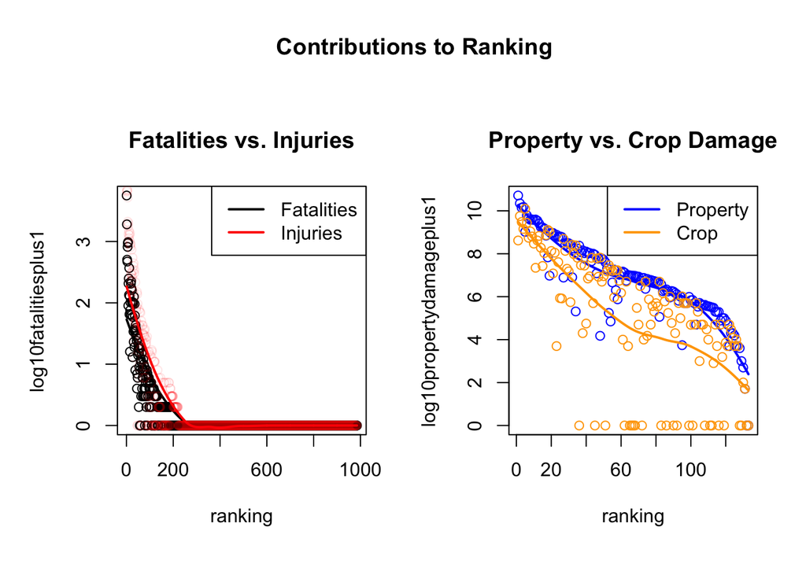

```r
## set up plot area for 2 columns and 1 row
par(mfrow=c(1,2), oma=c(1,1,4,0))
## first let's look at impact of fatalities and injuries to health impact ranking
with(dhealth, plot(ranking, log10fatalitiesplus1, col="black"))
lo <- loess(dhealth$log10fatalitiesplus1 ~ dhealth$ranking)
lines(predict(lo), col="black", lwd=2)

with(dhealth, points(ranking, log10injuriesplus1, col=rgb(1,0,0,alpha=.1)))
lo <- loess(dhealth$log10injuriesplus1 ~ dhealth$ranking)
lines(predict(lo), col="red", lwd=2)
legend("topright", c("Fatalities", "Injuries"), lty=c(1,1), col=c("black", "red"), lwd=c(2,2), bg="transparent")
title(main="Fatalities vs. Injuries")

## Now lets add the same for economic property and crop damage
with(deconomy, plot(ranking, log10propertydamageplus1, col="blue"))
lo <- loess(deconomy$log10propertydamageplus1 ~ deconomy$ranking)
lines(predict(lo), col="blue", lwd=2)
with(deconomy, points(ranking, log10cropdamageplus1, col="orange"))
lo <- loess(deconomy$log10cropdamageplus1 ~ deconomy$ranking)
lines(predict(lo), col="orange", lwd=2)
legend("topright", c("Property", "Crop"), lty=c(1,1), col=c("blue", "orange"), lwd=c(2,2), bg="transparent")
title(main="Property vs. Crop Damage")

title(main="Contributions to Ranking", outer = TRUE)
```

## Results

This analysis is a very simple one and it could easily be argued there are multiple angles not explored here. Our results are simply a quantification score for the both health and economic impact. Fatalities are worth 4x, injury is 1x and summed together for the health impact score. Our economic impact is simply a sum of $ costs of both property damage and crop damage.

Below are the top 20 most impactful event types for both health related and economic impact.

```r
dhealth[1:20, c("eventtype", "healthimpactscore")]  ## top 20 event types for health related impact
```

| eventtype | healthimpactscore |
| --- | --- |
| TORNADO | 113519 |
| EXCESSIVE HEAT | 14137 |
| TSTM WIND | 8973 |
| FLOOD | 8669 |
| LIGHTNING | 8494 |
| HEAT | 5848 |
| FLASH FLOOD | 5689 |
| ICE STORM | 2331 |
| WINTER STORM | 2145 |
| HIGH WIND | 2129 |

[output cut: 10 more lines]

```r
deconomy[1:20, c("eventtype", "economicimpactscore")]  ## tp 20 event for economy related impact
```

| eventtype | economicimpactscore |
| --- | --- |
| TORNADO | 52037263590 |
| FLOOD | 27819678250 |
| HAIL | 16952904170 |
| FLASH FLOOD | 16562128610 |
| DROUGHT | 13518672000 |
| HURRICANE | 8910229010 |
| TSTM WIND | 5038935790 |
| HURRICANE/TYPHOON | 4903712800 |
| HIGH WIND | 4608617560 |
| WILDFIRE | 4020586800 |

[output cut: 10 more lines]